# Comparison of donors and recipients in the St Louis and the Cryostem cohorts

Helena

29/03/2021

# CyTOF data

I can re-use the St Louis table, as it was generated in the markdown "markdown_cytof_st_louis_12_12_19.Rmd. The table contained the couple values (i.e. donor - recipient per couple). It gives, for every couple, D-R values for the percentage of cells in the 40 metaclusters, as well as the percentage of cells that were positive for the different functional markers:

I also extract clinical information on these patients (the recipients age, gender compatibility, the CMV status of donors and recipients, ...)

```
## [1] "0"
```

```
## [1] "1"
```

```
##    Id.Cryostem.R              GROUP GENDER        DOG TIMEPPOINT gender_comp
## 1          R2498       non_tolerant      F 2014-08-06         Y2          FF
## 3          R1503   primary_tolerant      M 2014-01-02         Y2          FM
## 6          R2032 secondary_tolerant      M 2014-04-22         Y2          MM
## 9          R1044   primary_tolerant      M 2013-09-12         Y2          MM
## 10         R2798 secondary_tolerant      F 2014-10-06         Y2          FF
## 11          R346       non_tolerant      F 2013-04-03         Y2          FF
##    age_recip cmv_comp
## 1      21794       01
## 3       8264       11
## 6      15701       00
## 9       7859       00
## 10     11254       11
## 11     17617       11
```

I also extract the table of CyTOF features in the Cryostem cohort, that contains the values of donors - recipients as generated in the markdown "markdown_cytof_st_louis_12_12_19":

And the clinical information for the Cryostem cohort:

```
## [1] 1
```

```
## [1] 1
```

```
##    Gender   HOSPITAL DATEOFCYTOFEXPERIMENT              group gender_comp
## 1       F CHU Angers            15.09.2017       non_tolerant          MF
## 10      F CHU Angers            21.09.2017   primary_tolerant          FF
## 11      F CHU Angers            21.09.2017   primary_tolerant          FF
## 12      M CHU Angers            21.09.2017   primary_tolerant          MM
## 13      F CHU Angers            21.09.2017       non_tolerant          MF
## 14      F CHU Angers            21.09.2017 secondary_tolerant          FF
##    age_recip cmv_comp
## 1      19529       11
## 10     16936       11
## 11     12009       00
## 12     22713      0NA
## 13     17236       00
## 14     12793       00
```

## Comparison of primary tolerant donors vs recipients

I apply a wilcoxon test for each feature, to determine whether the "donor-minus-recipient" values for this feature are significantly different from zero or not. A small p-value means that the D-R values were significantly different from zero, and thus that the values of donors were significantly different from the values of the recipients.

I first adjust the p-values in the Cryostem cohort, to take into account the fact that we perform multiple tests, using the TSBH correction.

We will now focus on the features that had an adjusted p-value < 0.05 in the Cryostem cohort, and a p-value < 0.05 in the St Louis cohort (as the small amount of patients prevents us from drawing conclusions from this cohort directly). To assess whether the effect observed in the Cryostem cohort holds in the St Louis cohort, we perform a study on the effect size.

```
## [1] "112 features were retained in the Cryostem cohort with an adjusted pvalue < 0.05"
```

```
## [1] "26 features were retained in the St Louis cohort with a pvalue < 0.05"
```

```
## [1] "11 features that were retained in the Cryostem cohort with an adjusted pvalue < 0.05 were also retained in the St Louis cohort with a pvalue < 0.05"
```

We select only the features that showed a consistent trend (the median D-R value is consistantly negative in both cohorts or positive in both cohorts).

```
## [1] "9 of these features were consistently positive of negative in both cohorts."
```

Here is a density plot that represents the distributions of the donor-recipient values for the first selected feature, in both cohorts. The density plots corresponding to the other selected features are plotted in a PDF file. When the values are mainly negative in these density plots, the feature was more expressed in recipients than in donors. On the other hand, features in which the vaues are mainly positive in both cohorts were more expressed in donors than in recipients.

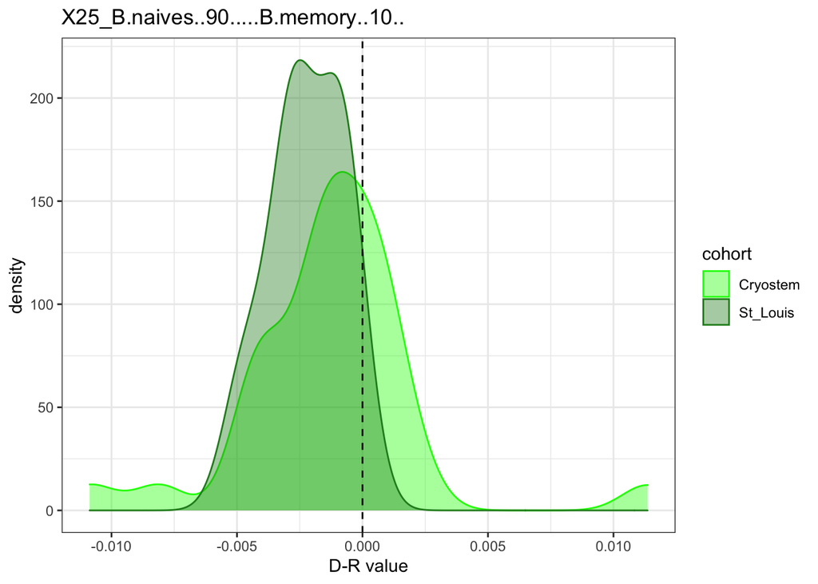

We can also represent the information under the form of a boxplot, in which the values of donors and recipients of the same couple can be seen, in both cohorts.

Again, the boxplots corresponding to all selected features are printed in a PDF file.

```
## Note: Using an external vector in selections is ambiguous.
## ℹ Use `all_of(ft)` instead of `ft` to silence this message.
## ℹ See <https://tidyselect.r-lib.org/reference/faq-external-vector.html>.
```

```
## Note: Using an external vector in selections is ambiguous.
## ℹ Use `all_of(i)` instead of `i` to silence this message.
## ℹ See <https://tidyselect.r-lib.org/reference/faq-external-vector.html>.
```

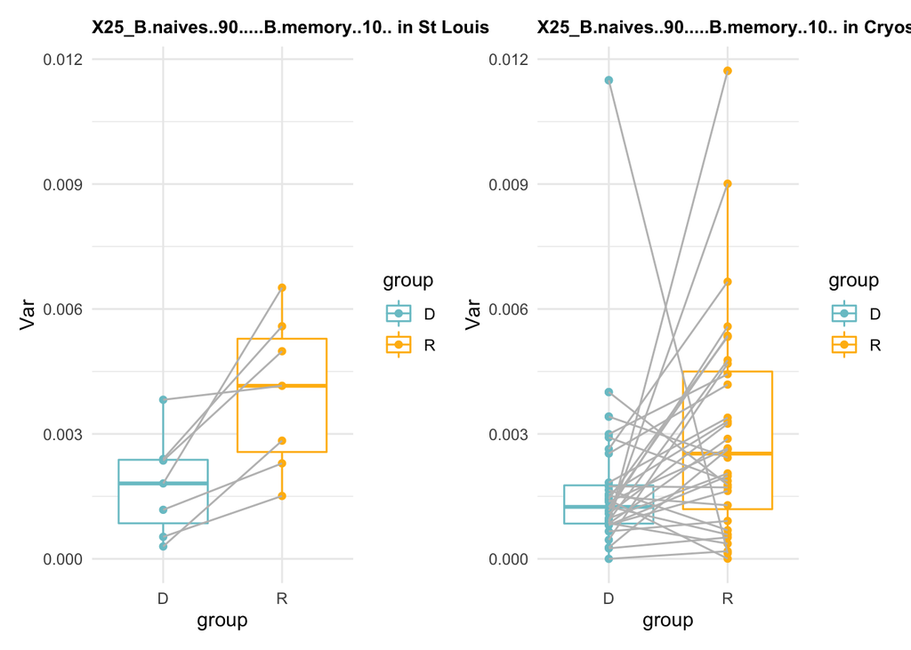

## Comparison of secondary tolerant donors vs recipients

I apply a wilcoxon test for each feature (D-R), to determine whether it is significantly different from zero or not. A small p-value means that the D-R values were significantly different from zero, and thus that the values of donors were significantly different from the values of the recipients.

I first adjust the p-values in the Cryostem cohort, to take into account the fact that we perform multiple tests, using the TSBH correction.

We will now focus on the features that had an adjusted p-value < 0.05 in the Cryostem cohort, and a p-value < 0.05 in the St Louis cohort (as the small amount of patients prevents us from drawing conclusions from this cohort directly). To assess whether the effect observed in the Cryostem cohort holds in the St Louis cohort, we perform a study on the effect size.

```
## [1] "4 features were retained in the Cryostem cohort with an adjusted pvalue < 0.05"
```

```
## [1] "6 features were retained in the St Louis cohort with a pvalue < 0.05"
```

```
## [1] "0 features that were retained in the Cryostem cohort with an adjusted pvalue < 0.05 were also retained in the St Louis cohort with a pvalue < 0.05"
```

## Comparison of non tolerant donors vs recipients

I apply a wilcoxon test for each feature (D-R), to determine whether it is significantly different from zero or not. A small p-value means that the D-R values were significantly different from zero, and thus that the values of donors were significantly different from the values of the recipients.

I first adjust the p-values in the Cryostem cohort, to take into account the fact that we perform multiple tests, using the TSBH correction.

We will now focus on the features that had an adjusted p-value < 0.05 in the Cryostem cohort, and a p-value < 0.05 in the St Louis cohort (as the small amount of patients prevents us from drawing conclusions from this cohort directly). To assess whether the effect observed in the Cryostem cohort holds in the St Louis cohort, we perform a study on the effect size.

```
## [1] "41 features were retained in the Cryostem cohort with an adjusted pvalue < 0.05"
```

```
## [1] "176 features were retained in the St Louis cohort with a pvalue < 0.05"
```

```
## [1] "31 features that were retained in the Cryostem cohort with an adjusted pvalue < 0.05 were also retained in the St Louis cohort with a pvalue < 0.05"
```

We select only the features that showed a consistent trend (the median D-R value is consistantly negative in both cohorts or positive in both cohorts).

```
## [1] "31 of these features were consistently positive of negative in both cohorts."
```

Here is a density plot that represents the distributions of the donor-recipient values for the first selected feature, in both cohorts. The density plots corresponding to the other selected features are plotted in a PDF file. When the values are mainly negative in these density plots, the feature was more expressed in recipients than in donors. On the other hand, features in which the vaues are mainly positive in both cohorts were more expressed in donors than in recipients.

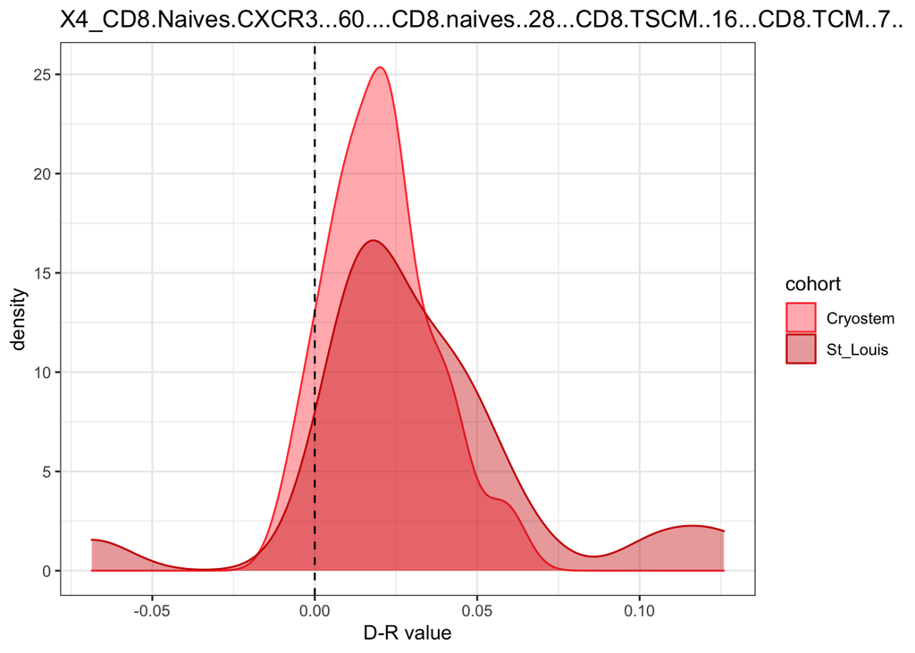

We can also represent the information under the form of a boxplot, in which the values of donors and recipients of the same couple can be seen, in both cohorts.

Again, the boxplots corresponding to all selected features are printed in a PDF file.

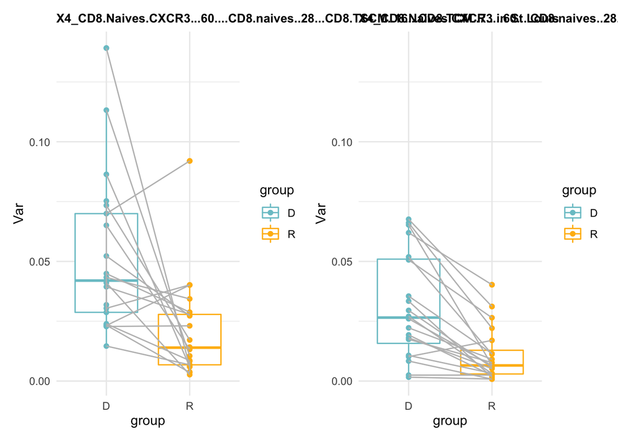

# Metabolomics data

I can re-use the St Louis table, as it was generated in the markdown "markdown_metabo_st_louis_3/01/20.Rmd". The table contained the couple values (i.e. donor - recipient per couple). It gives, for every couple, D-R values for the metabolites:

I also extract the table of metabolites in the Cryostem cohort, that contains the values of donors - recipients as generated in the markdown "markdown_metabo_cryostem_3/01/2020":

## Comparison of primary tolerant donors vs recipients

I apply a wilcoxon test for each feature, to determine whether the "donor-minus-recipient" values for this feature are significantly different from zero or not. A small p-value means that the D-R values were significantly different from zero, and thus that the values of donors were significantly different from the values of the recipients.

I first adjust the p-values in the Cryostem cohort, to take into account the fact that we perform multiple tests, using the TSBH correction.

We will now focus on the features that had an adjusted p-value < 0.05 in the Cryostem cohort, and a p-value < 0.05 in the St Louis cohort (as the small amount of patients prevents us from drawing conclusions from this cohort directly). To assess whether the effect observed in the Cryostem cohort holds in the St Louis cohort, we perform a study on the effect size.

```
## [1] "0 features were retained in the Cryostem cohort with an adjusted pvalue < 0.05"
```

```
## [1] "30 features were retained in the St Louis cohort with a pvalue < 0.05"
```

```
## [1] "0 features that were retained in the Cryostem cohort with an adjusted pvalue < 0.05 were also retained in the St Louis cohort with a pvalue < 0.05"
```

## Comparison of secondary tolerant donors vs recipients

I apply a wilcoxon test for each feature (D-R), to determine whether it is significantly different from zero or not. A small p-value means that the D-R values were significantly different from zero, and thus that the values of donors were significantly different from the values of the recipients.

I first adjust the p-values in the Cryostem cohort, to take into account the fact that we perform multiple tests, using the TSBH correction.

We will now focus on the features that had an adjusted p-value < 0.05 in the Cryostem cohort, and a p-value < 0.05 in the St Louis cohort (as the small amount of patients prevents us from drawing conclusions from this cohort directly). To assess whether the effect observed in the Cryostem cohort holds in the St Louis cohort, we perform a study on the effect size.

```
## [1] "0 features were retained in the Cryostem cohort with an adjusted pvalue < 0.05"
```

```
## [1] "25 features were retained in the St Louis cohort with a pvalue < 0.05"
```

```
## [1] "0 features that were retained in the Cryostem cohort with an adjusted pvalue < 0.05 were also retained in the St Louis cohort with a pvalue < 0.05"
```

## Comparison of non tolerant donors vs recipients

I apply a wilcoxon test for each feature (D-R), to determine whether it is significantly different from zero or not. A small p-value means that the D-R values were significantly different from zero, and thus that the values of donors were significantly different from the values of the recipients.

I first adjust the p-values in the Cryostem cohort, to take into account the fact that we perform multiple tests, using the TSBH correction.

We will now focus on the features that had an adjusted p-value < 0.05 in the Cryostem cohort, and a p-value < 0.05 in the St Louis cohort (as the small amount of patients prevents us from drawing conclusions from this cohort directly). To assess whether the effect observed in the Cryostem cohort holds in the St Louis cohort, we perform a study on the effect size.

```
## [1] "0 features were retained in the Cryostem cohort with an adjusted pvalue < 0.05"
```

```
## [1] "174 features were retained in the St Louis cohort with a pvalue < 0.05"
```

```
## [1] "0 features that were retained in the Cryostem cohort with an adjusted pvalue < 0.05 were also retained in the St Louis cohort with a pvalue < 0.05"
```

# Transcriptomics data

## Comparison of primary tolerant donors vs recipients

I apply a wilcoxon test for each feature, to determine whether the "donor-minus-recipient" values for this feature are significantly different from zero or not. A small p-value means that the D-R values were significantly different from zero, and thus that the values of donors were significantly different from the values of the recipients.

I first adjust the p-values in the Cryostem cohort, to take into account the fact that we perform multiple tests, using the TSBH correction.

We will now focus on the features that had an adjusted p-value < 0.05 in the Cryostem cohort, and a p-value < 0.05 in the St Louis cohort (as the small amount of patients prevents us from drawing conclusions from this cohort directly). To assess whether the effect observed in the Cryostem cohort holds in the St Louis cohort, we perform a study on the effect size.

```
## [1] "3635 features were retained in the Cryostem cohort with an adjusted pvalue < 0.05"
```

```
## [1] "1430 features were retained in the St Louis cohort with a pvalue < 0.05"
```

```
## [1] "599 features that were retained in the Cryostem cohort with an adjusted pvalue < 0.05 were also retained in the St Louis cohort with a pvalue < 0.05"
```

We select only the features that showed a consistent trend (the median D-R value is consistantly negative in both cohorts or positive in both cohorts).

```
## [1] "464 of these features were consistently positive of negative in both cohorts."
```

I also save information such as the pvalue, median, for the retained features, for eventual gene ontology analyses.

## Comparison of secondary tolerant donors vs recipients

I apply a wilcoxon test for each feature (D-R), to determine whether it is significantly different from zero or not. A small p-value means that the D-R values were significantly different from zero, and thus that the values of donors were significantly different from the values of the recipients.

I first adjust the p-values in the Cryostem cohort, to take into account the fact that we perform multiple tests, using the TSBH correction.

We will now focus on the features that had an adjusted p-value < 0.05 in the Cryostem cohort, and a p-value < 0.05 in the St Louis cohort (as the small amount of patients prevents us from drawing conclusions from this cohort directly). To assess whether the effect observed in the Cryostem cohort holds in the St Louis cohort, we perform a study on the effect size.

```
## [1] "766 features were retained in the Cryostem cohort with an adjusted pvalue < 0.05"
```

```
## [1] "82 features were retained in the St Louis cohort with a pvalue < 0.05"
```

```
## [1] "1 features that were retained in the Cryostem cohort with an adjusted pvalue < 0.05 were also retained in the St Louis cohort with a pvalue < 0.05: subst_MOCS1"
```

We select only the features that showed a consistent trend (the median D-R value is consistantly negative in both cohorts or positive in both cohorts).

```
## [1] "1 of these features were consistently positive of negative in both cohorts."
```

Here is a density plot that represents the distributions of the donor-recipient values for the first selected feature, in both cohorts. When the values are mainly negative in these density plots, the feature was more expressed in recipients than in donors. On the other hand, features in which the vaues are mainly positive in both cohorts were more expressed in donors than in recipients.

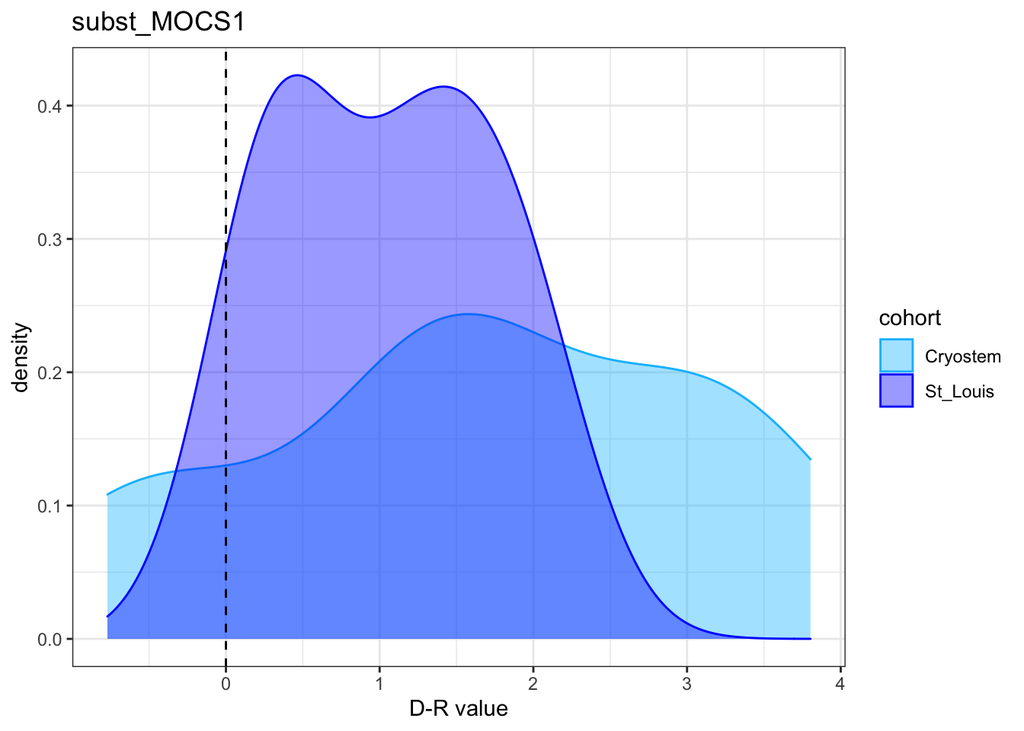

We can also represent the information under the form of a boxplot, in which the values of donors and recipients of the same couple can be seen, in both cohorts.

Again, the boxplots corresponding to all selected features are printed in a PDF file.

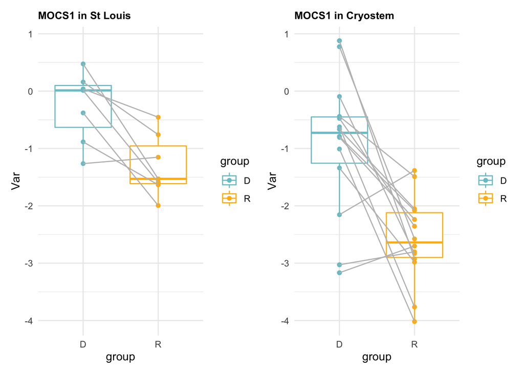

## Comparison of non tolerant donors vs recipients

I apply a wilcoxon test for each feature (D-R), to determine whether it is significantly different from zero or not. A small p-value means that the D-R values were significantly different from zero, and thus that the values of donors were significantly different from the values of the recipients.

I first adjust the p-values in the Cryostem cohort, to take into account the fact that we perform multiple tests, using the TSBH correction.

We will now focus on the features that had an adjusted p-value < 0.05 in the Cryostem cohort, and a p-value < 0.05 in the St Louis cohort (as the small amount of patients prevents us from drawing conclusions from this cohort directly). To assess whether the effect observed in the Cryostem cohort holds in the St Louis cohort, we perform a study on the effect size.

```
## [1] "1666 features were retained in the Cryostem cohort with an adjusted pvalue < 0.05"
```

```
## [1] "3747 features were retained in the St Louis cohort with a pvalue < 0.05"
```

```
## [1] "1159 features that were retained in the Cryostem cohort with an adjusted pvalue < 0.05 were also retained in the St Louis cohort with a pvalue < 0.05"
```

We select only the features that showed a consistent trend (the median D-R value is consistantly negative in both cohorts or positive in both cohorts).

```
## [1] "1159 of these features were consistently positive or negative in both cohorts."
```

I also save information such as the pvalue, median, for the retained features, for eventual gene ontology analyses.